# Understanding LIME

Katherine Goode

November 18, 2019

This journal contains information from the work I did to understand LIME. This includes a description of the LIME procedure from the original paper, a description of the functions in the in the *lime* R package, information about the Python *lime* package, and ideas for new binning methods.

```r
# Load packages
library(assertthat)
library(cowplot)
library(furrr)
library(future)
library(glmnet)
library(gower)
library(lime)
library(randomForest)
library(tidyverse)

# Source functions
source("../../code/helper_functions.R")
```

# Original Paper

Here, I have copied in the section of the original paper that describes LIME and put it in a more organized format. I have also added in some comments explaining my interpretation of the text and questions where I am not sure what is meant by the text.

## Notation

*Note: Most of the text in this section is copied from the original paper.*

| Notation | Original Paper Definition | My Interpretation (in terms of a data table) |
| --- | --- | --- |
| $x\in\mathbb{R}^d$ | Original representation of an instance being explained | Vector of observed features for one observation e.g. $(x_1, x_2,...,x_d)$ where $\textbf{X}$ is an $n$ by $d$ matrix |
| $f:\mathbb{R}^d→\mathbb{R}$ | The model being explained…In classification, $f(x)$ is the probability (or a binary indicator) that $x$ belongs to a certain class. | This is a random forest in our case. |
| $x'\in\{0,1\}^{d'}$ | A binary vector for interpretable representation (where interpretable explanations are defined as “use a representation that is understandable by humans”) | Varies based on the simulation method used. It is unclear to us how the size of $d$ compares to $d'$. We think they left it vague, so that it could fit any situation ($d<d'$, $d=d'$, or $d>d'$) (One e… |
| $G$ | A class of potentially interpretable models, such as linear models, decision trees, or falling rule lists | I’m not sure what is considered $G$ in the R package - the fitting of the final ridge regression model or the ridge regression model used for feature selection? |
| $g$ | An explanation as a model…can be readily presented to the user with visual or textual artifacts…The domain of $g$ is $\{0,1\}^{d′}$, i.e. $g$ acts over absence/presence of the interpretable components | This could be a ridge regression model with the form $f(x) \sim x'_1 + x'_2 + \cdots + x'_{d'}$ |
| $\Omega(g)$ | A measure of complexity of the explanation $g\in G$. For example, for decision trees $\Omega(g)$ may be the depth of the tree, while for linear models, $\Omega(g)$ may be the number of non-zero weight… | Seemingly, this is based on how the weights are assigned to the data points. |
| $\pi_x(z)$ | A proximity measure between an instance $z$ to $x$, so as to define locality around $x$. | This could be the Gower distance. |
| $\mathcal{L}(f,g,\pi_x)$ | A measure of how unfaithful $g$ is in approximating $f$ in the locality defined by $\pi_x$. | Does the LIME R package ever consider this? |
| $z'\in\{0,1\}^{d′}$ | A perturbed sample…(which contains a fraction of the nonzero elements of $x′$) | It appears that they are creating the perturbations in a different way than the R package. |
| $z\in\mathbb{R}^d$ | The sample in the original representation | Again, this seems to be different than the R package. |
| $f(z)$ | Used as a label for the explanation model | This is the application of the complex model to the perturbed sample. |
| $\mathcal{Z}$ | Data set…of perturbed samples with the associated labels | This is the full simulated dataset of perturbations and complex model predictions. |
| $\xi(x)$ | The explanation produced by LIME…$\underset{g∈G}{\arg\min} \ \mathcal{L}(f,g,\pi_x) + \Omega(g)$ | The output from the explanation model which is found through an optimization process. |

## Goal of LIME

In order to ensure both interpretability and local fidelity, we must minimize $\mathcal{L}(f,g,\pi_x)$ while having $\Omega(g)$ below enough to be interpretable by humans. The explanation produced by LIME is obtained by the following:
$$\xi(x) = \underset{g∈G}{\arg\min} \ \mathcal{L}(f,g,\pi_x) + \Omega(g)$$
This formulation can be used with different explanation families $G$, fidelity functions $\mathcal{L}$, and complexity measures $\Omega$. Here we focus on sparse linear models as explanations, and on performing the search using perturbations.

## Procedure

We want to minimize the locality-aware loss $\mathcal{L}(f,g, \pi_x)$ without making any assumptions about $f$, since we want the explainer to be model-agnostic.

| Step Number | Paper Description | My Interpretation |
| --- | --- | --- |
| 1 | In order to learn the local behavior of $f$ as the interpretable inputs vary, we approximate $\mathcal{L}(f,g,\pi_x)$ by drawing samples, weighted by $\pi_x$. | I don’t understand how drawing these samples approximates $\mathcal{L}(f,g,\pi_x)$ |
| 2 | We sample instances around $x'$ by drawing nonzero elements of $x'$ uniformly at random (where the number of such draws is also uniformly sampled). | What is meant by drawing elements of $x'$? Is this different than what the R package is doing? I’m wondering if the idea is that $x'=(x'_1, x'_2,...,x'_{d'})=(1, 1, ...., 1)$, and then a sample is tak… |
| 3 | Given a perturbed sample $z'\in\{0,1\}^{d′}$ (which contains a fraction of the nonzero elements of $x'$), we recover the sample in the original representation $z\in\mathbb{R}^d$ and obtain $f(z)$, whi… | How is the original sample recovered? Maybe based on my example in the last step $z=(0, x_2, 0, 0, x_5, ..., x_d)$ |
| 4 | Given this data set $\mathcal{Z}$ of perturbed samples with the associated labels, we optimize $\mathcal{L}(f,g,\pi_x) + \Omega(g)$ to get an explanation $\xi(x)$. | Where is this done in the R package? |

It is worth noting that our method is fairly robust to sampling noise since the samples are weighted by $\pi_x$. Okay - but this will really depend on how $\pi_x$ is chosen

…let $G$ be the class of linear models, such that $g(z′)=w_g\cdot z′$. (What is $w_g$? Is this suppose to be a linear model where $w_g$ are the coefficients?) We use the locally weighted square loss as $\mathcal{L}$…where we let
$$\pi_x(z)=exp(−D(x,z)^2/\sigma^2)$$
be an exponential kernel defined on some distance function $D$ (e.g. cosine distance for text, $L2$ distance or images) with width $\sigma$.
$$\mathcal{L}(f,g,\pi_x)=\sum_{z, z'\in\mathcal{Z}}\pi_x(z)\left(f(z)-g(z')\right)^2$$

## Comment on Faithfulness

…our choice of $G$ (sparse linear models) means that if the underlying model is highly non-linear even in the locality of the prediction, there may not be a faithful explanation. However, we can estimate the faithfulness of the explanation on $\mathcal{Z}$, and present this information to the user. This estimate of faithfulness can also be used for selecting an appropriate family of explanations from a set of multiple interpretable model classes, thus adapting to the given dataset and the classifier. We leave such exploration for future work, as linear explanations work quite well for multiple black-box models in our experiments.

# R Package

This section describes the procedure the the *lime* R package implements. The version of the `lime` package that is considered here is 0.5.1. The version considered when I first wrote this section was 0.5.0. I am only considering the `data.frame` versions of the functions. In order to determine if any of the functions that I am interested in have changed since I wrote the description, I created the function below that allows me to check if anything has changed in the function. If nothing has changed, it then prints the function.

```r
# Function for checking for changes in a function and printing the current version
func_check <- function(func_name, version){

  # Specify the path to where the function will be stored
  file_path <- paste0("../../../data/lime_functions/", func_name, "_v", version, ".rds")

  # Save the file if it does not exist, otherwise load the function and check
  # to make sure they have been no changes
  if(!file.exists(file_path)) {
    saveRDS(object = getAnywhere(func_name), file = file_path)
  } else {
    saved_func <- readRDS(file_path)
    assertthat::assert_that(assertthat::are_equal(saved_func,
                                                  getAnywhere(func_name)))
  }

  # Print the function
  getAnywhere(func_name)

}
```

In order to run the *lime* functions, here I load the bullet data to apply the code to.

```r
# Load in the bullet training and testing data
hamby173and252_train <- read.csv("../../../data/hamby173and252_train.csv")
hamby224_test <- read.csv("../../../data/hamby224_test.csv")

# Obtain features used when fitting the rtrees random forest
rf_features <- rownames(bulletr::rtrees$importance)
```

## Main Functions

### `lime.data.frame`

- `x`: The training data used to fit the model to be explained
- `model`: The model to explain.
- `preprocess = NULL`: Function to transform a character vector to the format expected from the model.
- `bin_continuous = TRUE`: If set to `TRUE`, the continuous variables will be binned when making the explanations. If they are not binned, then perturbations will be obtained by either simulating using kernel density estimation or a normal distribution depending on what the option of `use_density` is set to.
- `n_bins = 4`: The number of bins to use if `bin_continuous = TRUE`.
- `quantile_bins = TRUE`: Should quantile bins be used if `bin_continuous = TRUE? (Otherwise, equally spaced bins will be used.)
- `use_density = TRUE`: This option is only considered if `bin_continuous` is set to `FALSE`. In that situation, if `use_density = TRUE`, then the continuous data will be sampled using kernel density estimation. Otherwise, it will be assumed that the continuous features follow a normal distribution and samples will be drawn from a normal distribution with the mean and standard deviation set to the sample mean and standard deviation associated with the feature.

#### Procedure

1. If `preprocess` is NULL, then set it to the identity function. Either way, check to make sure that it is a function.

   ```
    if (is.null(preprocess))
      preprocess <- function(x) x
    assert_that(is.function(preprocess))
   ```

2. Create an explainer object.

   ```
    explainer <- c(as.list(environment()), list(...))
    explainer$x <- NULL
   ```

3. Determine the type of each of the features (e.g. integer, numeric, etc.). If any of the variables are constants, a warning is returned. If the feature type is unknown, an error is returned.

   ```
    explainer$feature_type <- setNames(sapply(x, function(f) {
      if (is.integer(f)) {
        if (length(unique(f)) == 1)
             "constant"
         else "integer"
      }
      else if (is.numeric(f)) {
        if (length(unique(f)) == 1)
             "constant"
        else "numeric"
      }
      else if (is.character(f)) {
        "character"
      }
      else if (is.factor(f)) {
        "factor"
      }
      else if (is.logical(f)) {
        "logical"
      }
      else if (inherits(f, "Date") || inherits(f, "POSIXt")) {
        "date_time"
      }
      else {
        stop("Unknown feature type", call. = FALSE)
      }
    }), names(x))
    if (any(explainer$feature_type == "constant")) {
      warning("Data contains numeric columns with zero variance",
        call. = FALSE)
    }
   ```

   ```
    explainer$bin_cuts <- setNames(lapply(seq_along(x), function(i) {
      if (explainer$feature_type[i] %in% c("numeric", "integer")) {
        if (quantile_bins) {
          bins <- quantile(x[[i]], seq(0, 1, length.out = n_bins +
            1), na.rm = TRUE)
          bins <- bins[!duplicated(bins)]
          if (length(bins) < 3) {
            warning(names(x)[i], " does not contain enough variance to use
            quantile binning. Using standard binning instead.",
              call. = FALSE)
            d_range <- range(x[[i]], na.rm = TRUE)
            bins <- seq(d_range[1], d_range[2], length.out = n_bins + 1)
          }
          bins
        }
        else {
          d_range <- range(x[[i]], na.rm = TRUE)
          seq(d_range[1], d_range[2], length.out = n_bins + 1)
        }
      }
    }), names(x))
   ```

     ```
     explainer$feature_distribution <- setNames(lapply(seq_along(x),
         function(i) {
           switch(explainer$feature_type[i],
             integer = ,
             numeric = if (bin_continuous) {
               table(cut(x[[i]], unique(explainer$bin_cuts[[i]]),
                 labels = FALSE, include.lowest = TRUE))/nrow(x)
             } else if (use_density) {
               density(x[[i]])
             } else {
              c(mean = mean(x[[i]], na.rm = TRUE), sd = sd(x[[i]],
                na.rm = TRUE))
             }, character = , logical = , factor = table(x[[i]])/nrow(x),
              NA)
       }), names(x))
     ```

6. Assign some attributes to the explainer object, and return the explainer object.

   ```
    structure(explainer, class = c("data_frame_explainer", "explainer",
      "list"))
   ```

#### Function

```r
# Print the function (and check to see if there have been any changes)
func_check("lime.data.frame", "0.5.0")
```

```
## A single object matching 'lime.data.frame' was found
## It was found in the following places
##   registered S3 method for lime from namespace lime
##   namespace:lime
## with value
##
## function (x, model, preprocess = NULL, bin_continuous = TRUE,
##     n_bins = 4, quantile_bins = TRUE, use_density = TRUE, ...)
## {
##     if (is.null(preprocess))
##         preprocess <- function(x) x
##     assert_that(is.function(preprocess))
##     explainer <- c(as.list(environment()), list(...))
##     explainer$x <- NULL
##     explainer$feature_type <- setNames(sapply(x, function(f) {
##         if (is.integer(f)) {
##             if (length(unique(f)) == 1)
##                 "constant"
##             else "integer"
##         }
##         else if (is.numeric(f)) {
##             if (length(unique(f)) == 1)
##                 "constant"
##             else "numeric"
##         }
##         else if (is.character(f)) {
##             "character"
##         }
##         else if (is.factor(f)) {
##             "factor"
##         }
##         else if (is.logical(f)) {
##             "logical"
##         }
##         else if (inherits(f, "Date") || inherits(f, "POSIXt")) {
##             "date_time"
##         }
##         else {
##             stop("Unknown feature type", call. = FALSE)
##         }
```

[output cut: 30 more lines]

```
##                 table(cut(x[[i]], unique(explainer$bin_cuts[[i]]),
##                   labels = FALSE, include.lowest = TRUE))/nrow(x)
##             } else if (use_density) {
##                 density(x[[i]])
##             } else {
##                 c(mean = mean(x[[i]], na.rm = TRUE), sd = sd(x[[i]],
##                   na.rm = TRUE))
##             }, character = , logical = , factor = table(x[[i]])/nrow(x),
##                 NA)
##         }), names(x))
##     structure(explainer, class = c("data_frame_explainer", "explainer",
##         "list"))
## }
## <bytecode: 0x7f863cfa6ab0>
## <environment: namespace:lime>
```

### `explain.data.frame`

#### Procedure

1. Check to make sure that `explainer` is an object output from the `lime` function.

   ```
    assertthat::assert_that(is.data_frame_explainer(explainer))
   ```

2. Determine the type of the model that is contained within the explainer function (using the `model_type` function), and determine the type of output that should be produced by `explain` based on the model type (using the `output_type` function).

   ```
    m_type <- model_type(explainer)
    o_type <- output_type(explainer)
   ```

3. If the model type is regression, check to make sure both `labels` and `n_labels` are set to NULL. Otherwise, return a warning saying that labels and n_labels are ignored with explaining regression models. Then set `n_lables` to 1 and `labels` to NULL.

   ```
    if (m_type == "regression") {
      if (!is.null(labels) || !is.null(n_labels)) {
        warning("\"labels\" and \"n_labels\" arguments are ignored
          when explaining regression models")
      }
      n_labels <- 1
      labels <- NULL
    }
   ```

4. Check to make sure that only `labels` or `n_labels` is specified and the other is NULL. If not, output a warning saying that you must choose between one or the other.

   ```
    assert_that(is.null(labels) + is.null(n_labels) == 1,
      msg = "You need to choose between labels and n_labels parameters.")
   ```

5. Return an error if `n_features` or `n_permutations` are not specified as counts.

   ```
    assert_that(is.count(n_features))
    assert_that(is.count(n_permutations))
   ```

   ```
    if (is.null(kernel_width)) {
      kernel_width <- sqrt(ncol(x)) * 0.75
    }
    kernel <- exp_kernel(kernel_width)
   ```

7. Makes use of the `permute_cases` function for data frames in the lime package. This is the function that creates the perturbations. One perturbation is created for each of the `n_permuations` specified.

   ```
    case_perm <- permute_cases(x, n_permutations, explainer$feature_distribution,
      explainer$bin_continuous, explainer$bin_cuts, explainer$use_density)
   ```

8. Obtains predictions for all of the permutated data points based on the original model using the `predict_model` function. Use the function `set_labels`

   ```
    case_res <- predict_model(explainer$model,
      explainer$preprocess(case_perm),
      type = o_type, ...)
    case_res <- set_labels(case_res, explainer$model)
   ```

9. Creates indicies for each of the perturbations and dividing them into groups based on which new prediction case they correspond to

   ```
    case_ind <- split(seq_len(nrow(case_perm)), rep(seq_len(nrow(x)), each = n_permutations))
   ```

10. Fill in the results obejct

    ```
    res <- lapply(seq_along(case_ind), function(ind) {
    ```

11. Create a vector of indicies for one of the observations

    ```
    i <- case_ind[[ind]]
    ```

12. If the distance function is specified to be “gower”, then compute the distance between the case of interest and each observation in the permuted dataset. These distances get raised to whatever the specified `gower_pow` is. Then these values are subtracted from one so that observations closer to the case of interest have a higher “weight” associated with them.

    ```
    if (dist_fun == "gower") {
      sim <- 1 - (gower_dist(case_perm[i[1], , drop = FALSE],
        case_perm[i, , drop = FALSE]))^gower_pow
    }
    ```

13. Turns the factor and character variables into numeric variables and determines whether a permutation falls into the test data bin if bins_continuous is set to TRUE. This uses the `numerify` function.

    ```
    perms <- numerify(case_perm[i, ], explainer$feature_type, explainer$bin_continuous, explainer$bin_cuts)
    ```

14. If the distance is not set to “gower”, then distance between the case of interest and the permutations is computed using the kernel function. This also makes use of the `feature_scale` function.

    ```
    if (dist_fun != "gower") {
      sim <- kernel(c(0, dist(feature_scale(perms, explainer$feature_distribution,
        explainer$feature_type, explainer$bin_continuous),
        method = dist_fun)[seq_len(n_permutations - 1)]))
    }
    ```

15. Perform feature selection and fit a model to the permutations using these important variables using the function `model_permutations`.

    ```
    res <- model_permutations(as.matrix(perms), case_res[i, , drop = FALSE], sim, labels, n_labels, n_features, feature_select)
    ```

16. Finish filling in the rest of the results object with information about bins and such. This makes use of the `describe_feature` function.

    ```
    res$feature_value <- unlist(case_perm[i[1], res$feature])
    res$feature_desc <- describe_feature(res$feature, case_perm[i[1], ], explainer$feature_type,
      explainer$bin_continuous, explainer$bin_cuts)
    guess <- which.max(abs(case_res[i[1], ]))
    res$case <- rownames(x)[ind]
    res$label_prob <- unname(as.matrix(case_res[i[1], ]))[match(res$label, colnames(case_res))]
    res$data <- list(as.list(case_perm[i[1], ]))
    res$prediction <- list(as.list(case_res[i[1], ]))
    res$model_type <- m_type
    res
    ```

17. Join the results and assign names to the columns

    ```
    res <- do.call(rbind, res)
    res <- res[, c('model_type', 'case', 'label', 'label_prob', 'model_r2',
                   'model_intercept', 'model_prediction', 'feature', 'feature_value',
                   'feature_weight', 'feature_desc', 'data', 'prediction')]
    if (m_type == 'regression') {
      res$label <- NULL
      res$label_prob <- NULL
      res$prediction <- unlist(res$prediction)
    }
    ```

18. Return the results object

    ```
    res
    ```

#### Function

```r
# Print the function (and check to see if there have been any changes)
func_check("explain.data.frame", "0.5.0")
```

```
## A single object matching 'explain.data.frame' was found
## It was found in the following places
##   namespace:lime
## with value
##
## function (x, explainer, labels = NULL, n_labels = NULL, n_features,
##     n_permutations = 5000, feature_select = "auto", dist_fun = "gower",
##     kernel_width = NULL, gower_pow = 1, ...)
## {
##     assert_that(is.data_frame_explainer(explainer))
##     m_type <- model_type(explainer)
##     o_type <- output_type(explainer)
##     if (m_type == "regression") {
##         if (!is.null(labels) || !is.null(n_labels)) {
##             warning("\"labels\" and \"n_labels\" arguments are ignored when explaining regression models")
##         }
##         n_labels <- 1
##         labels <- NULL
##     }
##     assert_that(is.null(labels) + is.null(n_labels) == 1, msg = "You need to choose between labels and n_labels parameters.")
##     assert_that(is.count(n_features))
##     assert_that(is.count(n_permutations))
##     if (is.null(kernel_width)) {
##         kernel_width <- sqrt(ncol(x)) * 0.75
##     }
##     kernel <- exp_kernel(kernel_width)
##     case_perm <- permute_cases(x, n_permutations, explainer$feature_distribution,
##         explainer$bin_continuous, explainer$bin_cuts, explainer$use_density)
##     case_res <- predict_model(explainer$model, explainer$preprocess(case_perm),
##         type = o_type, ...)
##     case_res <- set_labels(case_res, explainer$model)
##     case_ind <- split(seq_len(nrow(case_perm)), rep(seq_len(nrow(x)),
##         each = n_permutations))
##     res <- lapply(seq_along(case_ind), function(ind) {
##         i <- case_ind[[ind]]
##         if (dist_fun == "gower") {
##             sim <- 1 - (gower_dist(case_perm[i[1], , drop = FALSE],
##                 case_perm[i, , drop = FALSE]))^gower_pow
##         }
##         perms <- numerify(case_perm[i, ], explainer$feature_type,
```

[output cut: 21 more lines]

```
##     })
##     res <- do.call(rbind, res)
##     res <- res[, c("model_type", "case", "label", "label_prob",
##         "model_r2", "model_intercept", "model_prediction", "feature",
##         "feature_value", "feature_weight", "feature_desc", "data",
##         "prediction")]
##     if (m_type == "regression") {
##         res$label <- NULL
##         res$label_prob <- NULL
##         res$prediction <- unlist(res$prediction)
##     }
##     as_tibble(res)
## }
## <bytecode: 0x7f861f92fa50>
## <environment: namespace:lime>
```

#### Implementation

```r
library(randomForest)
x <- hamby224_test %>%
  arrange(case) %>%
  select(rf_features) %>%
  na.omit()
explainer <- lime:::lime.data.frame(x = hamby173and252_train %>%
                                      select(rf_features),
                                    y = hamby173and252_train %>%
                                      select(samesource),
                                    model = as_classifier(bulletr::rtrees))
label = TRUE
n_labels = NULL
n_features = 3
n_permutations = 5000
feature_select = 'auto'
dist_fun = "gower"
kernel_width = NULL
gower_pow = 1
```

```r
assertthat::assert_that(lime:::is.data_frame_explainer(explainer))
```

```
## [1] TRUE
```

```r
#m_type <- lime:::model_type(explainer)
o_type <- lime:::output_type(explainer)
```

```r
assert_that(is.null(labels) + is.null(n_labels) == 1,
   msg = "You need to choose between labels and n_labels parameters.")
```

```
## [1] TRUE
```

```r
assert_that(is.count(n_features))
```

```
## [1] TRUE
```

```r
assert_that(is.count(n_permutations))
```

```
## [1] TRUE
```

```r
if (is.null(kernel_width)) {
   kernel_width <- sqrt(ncol(x)) * 0.75
}
kernel <- lime:::exp_kernel(kernel_width)
```

```r
case_perm <- lime:::permute_cases.data.frame(x,
                                             n_permutations,
                                             explainer$feature_distribution,
                                             explainer$bin_continuous,
                                             explainer$bin_cuts,
                                             explainer$use_density)
head(case_perm)
```

```
##          ccf  rough_cor           D        sd_D    matches mismatches
## 1 0.27042215  0.2704221 0.001396367 0.002090586  0.5901742   7.616146
## 2 0.28724882 -0.1611515 1.013499988 3.019210854  2.9464410   9.556052
## 3 0.30790540  0.4078556 2.811572048 2.010342687  1.2441031   9.978211
## 4 0.04436213  0.9178336 2.110390058 6.498977479  1.6576612  25.502945
## 5 0.27896222 -0.1015974 3.398931097 1.996186637  3.0527158   1.367676
## 6 0.25113254 -0.1527809 4.492328696 4.553291926 16.8560805  32.680021
##          cms   non_cms sum_peaks
## 1 0.59017419  3.808073  1.463209
## 2 7.52621104  4.334388 20.818953
## 3 1.32867089 32.760953  3.568589
## 4 0.85718517  5.956968 23.968347
## 5 0.18317852 18.112314 12.565722
## 6 0.07182718  1.122142  4.000728
```

```r
case_res <- lime:::predict_model(explainer$model,
                                 explainer$preprocess(case_perm),
                                 type = o_type)
case_res <- lime:::set_labels(case_res, explainer$model)
head(case_res)
```

```
##       FALSE      TRUE
## 1 1.0000000 0.0000000
## 2 0.8066667 0.1933333
## 3 0.6633333 0.3366667
## 4 0.7766667 0.2233333
## 5 0.6833333 0.3166667
## 6 0.4833333 0.5166667
```

```r
case_ind <- split(seq_len(nrow(case_perm)), rep(seq_len(nrow(x)), each = n_permutations))
case_ind[[1]][1:10]
```

```
##  [1]  1  2  3  4  5  6  7  8  9 10
```

```r
case_ind[[2]][1:10]
```

```
##  [1] 5001 5002 5003 5004 5005 5006 5007 5008 5009 5010
```

```r
case_ind[[3]][1:10]
```

```
##  [1] 10001 10002 10003 10004 10005 10006 10007 10008 10009 10010
```

```r
str(seq_along(case_ind))
```

```
##  int [1:364] 1 2 3 4 5 6 7 8 9 10 ...
```

```r
i <- case_ind[[1]]
str(i)
```

```
##  int [1:5000] 1 2 3 4 5 6 7 8 9 10 ...
```

```r
if (dist_fun == "gower") {
  sim <- 1 - (gower_dist(case_perm[i[1], , drop = FALSE],
    case_perm[i, , drop = FALSE]))^gower_pow
}
str(sim)
```

```
##  num [1:5000] 1 0.765 0.82 0.653 0.795 ...
```

```r
perms <- lime:::numerify(case_perm[i, ],
                         explainer$feature_type,
                         explainer$bin_continuous,
                         explainer$bin_cuts)
head(perms)
```

```
##   ccf rough_cor D sd_D matches mismatches cms non_cms sum_peaks
## 1   1         1 1    1       1          1   1       1         1
## 2   0         0 1    0       0          0   0       1         0
## 3   0         1 0    1       0          0   0       0         0
## 4   0         1 0    0       0          0   0       0         0
## 5   0         0 0    1       0          1   1       0         0
## 6   1         0 0    0       0          0   1       0         0
```

```r
# error?
# res <- lime:::model_permutations(as.matrix(perms),
#                                  case_res[i, , drop = FALSE],
#                                  sim,
#                                  labels,
#                                  n_labels,
#                                  n_features,
#                                  feature_select)
```

## Helper Functions

These are listed in the order that they are used.

### `model_type`

- `x`: the model that is stored in the `explainer` object

#### Procedure

1. The function `model_type` is an overarching function that leads to the specific functions for determining the model type.

   ```
    model_type <- function (x, ...) {
                UseMethod("model_type")
              }
   ```

   The specific functions vary based on what package was used to fit the model. Here is information from the package documentation about models supported by *lime*.

   ```
    Out of the box, lime supports the following model objects:
        - train from caret
        - WrappedModel from mlr
        - xgb.Booster from xgboost
        - H2OModel from h2o
        - keras.engine.training.Model from keras
        - lda from MASS (used for low-dependency examples)
    If your model is not one of the above you'll need to implement support yourself. If the model has a predict interface mimicking that of predict.train() from caret, it will be enough to wrap your model in as_classifier()/as_regressor() to gain support. Otherwise you'll need need to implement a predict_model() method and potentially a model_type() method (if the latter is omitted the model should be wrapped in as_classifier()/as_regressor(), everytime it is used in lime()).
   ```

2. Apply the model specific function to determine the model type.
   - **default**

     ```
     stop("The class of model must have a model_type method. See ?model_type to get an overview of models supported out of the box", call. = FALSE)
     ```

   - **lime classifier**

     ```
       "classification"
     ```

   - **lime regressor**

     ```
       "regression"
     ```

   - **train**

     ```
       tolower(x$modelType)
     ```

   - **model fit**

     ```
       x$spec$mode
     ```

   - **Wrapped Model**

     ```
       switch(x$learner$type, classif = "classification", regr = "regression",
         surv = "survival", cluster = "clustering", multilabel = "multilabel")
     ```

   - **xgb Booster**

     ```
       obj <- x$params$objective
       if (is.null(obj))
         return("regression")
       if (is.function(obj))
         stop("Unsupported model type", call. = FALSE)
       type <- strsplit(obj, ":")[[1]][1]
       switch(type, reg = "regression", binary = "classification",
         multi = "classification", stop("Unsupported model type",
         call. = FALSE))
     ```

   - **lda**

     ```
       "classification"
     ```

   - **keras**

     ```
       if (!requireNamespace("keras", quietly = TRUE)) {
         stop("The keras package is required for predicting keras models")
       }
       num_layers <- length(x$layers)
       if (keras::get_config(keras::get_layer(x, index = num_layers))$activation == "linear") {
         "regression"
       }
       else {
         "classification"
       }
     ```

   - **ranger**

     ```
       ranger_model_class <- x$treetype
       if (ranger_model_class == "Probability estimation" || ranger_model_class == "Classification") {
         return("classification")
       }
       else if (ranger_model_class == "Regression") {
         return("regression")
       }
       else {
         stop(paste0("ranger model class \"", ranger_model_class,
           "\" is not currently supported."))
       }
     ```

#### Function

```r
func_check("model_type", "0.5.0")
```

```
## A single object matching 'model_type' was found
## It was found in the following places
##   package:lime
##   namespace:lime
## with value
##
## function (x, ...)
## {
##     UseMethod("model_type")
## }
## <bytecode: 0x7f863adb8200>
## <environment: namespace:lime>
```

```r
func_check("model_type", "0.5.0")
```

```
## A single object matching 'model_type' was found
## It was found in the following places
##   package:lime
##   namespace:lime
## with value
##
## function (x, ...)
## {
##     UseMethod("model_type")
## }
## <bytecode: 0x7f863adb8200>
## <environment: namespace:lime>
```

```r
func_check("model_type.default", "0.5.0")
```

```
## A single object matching 'model_type.default' was found
## It was found in the following places
##   registered S3 method for model_type from namespace lime
##   namespace:lime
## with value
##
## function (x, ...)
## {
##     stop("The class of model must have a model_type method. See ?model_type to get an overview of models supported out of the box",
##         call. = FALSE)
## }
## <bytecode: 0x7f863a9cf498>
## <environment: namespace:lime>
```

```r
func_check("model_type.lime_classifier", "0.5.0")
```

```
## A single object matching 'model_type.lime_classifier' was found
## It was found in the following places
##   registered S3 method for model_type from namespace lime
##   namespace:lime
## with value
##
## function (x, ...)
## "classification"
## <bytecode: 0x7f861f484d38>
## <environment: namespace:lime>
```

```r
func_check("model_type.lime_regressor", "0.5.0")
```

```
## A single object matching 'model_type.lime_regressor' was found
## It was found in the following places
##   registered S3 method for model_type from namespace lime
##   namespace:lime
## with value
##
## function (x, ...)
## "regression"
## <bytecode: 0x7f863a4d3cb0>
## <environment: namespace:lime>
```

```r
func_check("model_type.train", "0.5.0")
```

```
## A single object matching 'model_type.train' was found
## It was found in the following places
##   registered S3 method for model_type from namespace lime
##   namespace:lime
## with value
##
## function (x, ...)
## {
##     tolower(x$modelType)
## }
## <bytecode: 0x7f863a321dc8>
## <environment: namespace:lime>
```

```r
func_check("model_type.model_fit", "0.5.0")
```

```
## A single object matching 'model_type.model_fit' was found
## It was found in the following places
##   registered S3 method for model_type from namespace lime
##   namespace:lime
## with value
##
## function (x, ...)
## {
##     x$spec$mode
## }
## <bytecode: 0x7f863a157930>
## <environment: namespace:lime>
```

```r
func_check("model_type.WrappedModel", "0.5.0")
```

```
## A single object matching 'model_type.WrappedModel' was found
## It was found in the following places
##   registered S3 method for model_type from namespace lime
##   namespace:lime
## with value
##
## function (x, ...)
## {
##     switch(x$learner$type, classif = "classification", regr = "regression",
##         surv = "survival", cluster = "clustering", multilabel = "multilabel")
## }
## <bytecode: 0x7f8639fc31c0>
## <environment: namespace:lime>
```

```r
func_check("model_type.xgb.Booster", "0.5.0")
```

```
## A single object matching 'model_type.xgb.Booster' was found
## It was found in the following places
##   registered S3 method for model_type from namespace lime
##   namespace:lime
## with value
##
## function (x, ...)
## {
##     obj <- x$params$objective
##     if (is.null(obj))
##         return("regression")
##     if (is.function(obj))
##         stop("Unsupported model type", call. = FALSE)
##     type <- strsplit(obj, ":")[[1]][1]
##     switch(type, reg = "regression", binary = "classification",
##         multi = "classification", stop("Unsupported model type",
##             call. = FALSE))
## }
## <bytecode: 0x7f8639d990e0>
## <environment: namespace:lime>
```

```r
func_check("model_type.lda", "0.5.0")
```

```
## A single object matching 'model_type.lda' was found
## It was found in the following places
##   registered S3 method for model_type from namespace lime
##   namespace:lime
## with value
##
## function (x, ...)
## "classification"
## <bytecode: 0x7f8639b7a318>
## <environment: namespace:lime>
```

```r
func_check("model_type.keras.engine.training.Model", "0.5.0")
```

```
## A single object matching 'model_type.keras.engine.training.Model' was found
## It was found in the following places
##   registered S3 method for model_type from namespace lime
##   namespace:lime
## with value
##
## function (x, ...)
## {
##     if (!requireNamespace("keras", quietly = TRUE)) {
##         stop("The keras package is required for predicting keras models")
##     }
##     num_layers <- length(x$layers)
##     if (keras::get_config(keras::get_layer(x, index = num_layers))$activation ==
##         "linear") {
##         "regression"
##     }
##     else {
##         "classification"
##     }
## }
## <bytecode: 0x7f8639a28ba0>
## <environment: namespace:lime>
```

```r
func_check("model_type.H2OModel", "0.5.0")
```

```
## A single object matching 'model_type.H2OModel' was found
## It was found in the following places
##   registered S3 method for model_type from namespace lime
##   namespace:lime
## with value
##
## function (x, ...)
## {
##     h2o_model_class <- class(x)[[1]]
##     if (h2o_model_class %in% c("H2OBinomialModel", "H2OMultinomialModel")) {
##         return("classification")
##     }
##     else if (h2o_model_class == "H2ORegressionModel") {
##         return("regression")
##     }
##     else {
##         stop("This h2o model is not currently supported.")
##     }
## }
## <bytecode: 0x7f8639825b98>
## <environment: namespace:lime>
```

```r
func_check("model_type.ranger", "0.5.0")
```

```
## A single object matching 'model_type.ranger' was found
## It was found in the following places
##   registered S3 method for model_type from namespace lime
##   namespace:lime
## with value
##
## function (x, ...)
## {
##     ranger_model_class <- x$treetype
##     if (ranger_model_class == "Probability estimation" || ranger_model_class ==
##         "Classification") {
##         return("classification")
##     }
##     else if (ranger_model_class == "Regression") {
##         return("regression")
##     }
##     else {
##         stop(paste0("ranger model class \"", ranger_model_class,
##             "\" is not currently supported."))
##     }
## }
## <bytecode: 0x7f8638544f58>
## <environment: namespace:lime>
```

### `output_type`

- `x`: the model that is stored in the `explainer` object

#### Procedure

1. Identifies which model type the model is. If it is a classification model, then the output type is set to “prob”. If it is a regression model, then the output type is set to “raw”. If neither of these, then an error is returned saying that the model type that was input is not supported by the package.

   ```
    switch(model_type(x),
          classification = "prob",
          regression = "raw",
          stop(model_type(x), " models are not supported yet", call. = FALSE))
   ```

#### Function

```r
# Print the function (and check to see if there have been any changes)
func_check("output_type", "0.5.0")
```

```
## A single object matching 'output_type' was found
## It was found in the following places
##   namespace:lime
## with value
##
## function (x)
## {
##     switch(model_type(x), classification = "prob", regression = "raw",
##         stop(model_type(x), " models are not supported yet",
##             call. = FALSE))
## }
## <bytecode: 0x7f861f4868a0>
## <environment: namespace:lime>
```

### `exp_kernel`

- `width`: kernel width

#### Procedure

1. Create a function for computing an exponential kernel.

   ```
    function(x) sqrt(exp(-(x^2)/(width^2)))
   ```

#### Function

```r
# Print the function (and check to see if there have been any changes)
func_check("exp_kernel", "0.5.0")
```

```
## A single object matching 'exp_kernel' was found
## It was found in the following places
##   namespace:lime
## with value
##
## function (width)
## {
##     function(x) sqrt(exp(-(x^2)/(width^2)))
## }
## <bytecode: 0x7f863b2b9ce8>
## <environment: namespace:lime>
```

### `permute_cases`

- `cases`: the object `x` from `explain.data.frame` (new obs to explain)
- `n_permutations`: the object `n_permutations` from `explain.data.frame` (number of perturbations)
- `feature_distribution`: the object `explainer$feature_distribution` (the distribution of each feature computed from `lime.data.frame`)
- `bin_continuous`: the object `explainer$bin_continuous` determined from `lime.data.frame`
- `bin_cuts`: the object `explainer$bin_cuts` determined from `lime.data.frame`
- `use_density`: the object `explainer$use_density` determined from `lime.data.frame`

#### Procedure

1. Compute the number of rows as the number of predictions to be explained times the number of permutations.

   ```
    nrows <- nrow(cases) * n_permutations
   ```

2. Create the perturbations based on the type of variable and using the feature distribution determined by the lime function. The cases are as follows. The function does this process one variable at a time where a case represents on variable.

   ```
    perm <- as.data.frame(lapply(seq_along(cases), function(i) {
   ```

   - **numeric variable and feature distribution contains all NAs**: the observed cases get repeated `n_permutations` times

     ```
       perms <- if (is.numeric(cases[[i]]) && identical(is.na(feature_distribution[[i]]), TRUE)) {
       rep(cases[[i]], each = n_permutations)
       }
     ```

   - **numeric variable and `bin_continuous = TRUE`**: sample from 1:number of bin cuts with replacement for nrows times using the probability from the variable distribution sample from a uniform(0,1) distribution and then multiply by the difference in bin cuts of the appropriate bin and add the quantile associated with the bin

     ```
       else if (is.numeric(cases[[i]]) && bin_continuous) {
         bin <- sample(seq_along(feature_distribution[[i]]),
           nrows, TRUE, as.numeric(feature_distribution[[i]]))
         diff(bin_cuts[[i]])[bin] * runif(nrows) + bin_cuts[[i]][bin]
       }
     ```

   - **numeric variable, `bin_continuous = FALSE`, and `use_density = TRUE`**:

     ```
       else if (is.numeric(cases[[i]]) && use_density) {
         width <- diff(feature_distribution[[i]]$x[c(1, 2)])/2
         sample(feature_distribution[[i]]$x, nrows, TRUE,
           feature_distribution[[i]]$y) + runif(nrows, -width, width)
       }
     ```

   - **numeric variable, `bin_continuous = FALSE`, and `use_density = FALSE`**: randomly sample from a normal distribution, multiply by the sd of the feature distribution, and add the mean

     ```
       else if (is.numeric(cases[[i]])) {
          rnorm(nrows) * feature_distribution[[i]]["sd"] +
              feature_distribution[[i]]["mean"]
       }
     ```

   - **character variable**: sample from the names of the levels in the variable based on the probability of the variable distribution

     ```
       else if (is.character(cases[[i]])) {
          sample(names(feature_distribution[[i]]), nrows, TRUE,
              as.numeric(feature_distribution[[i]]))
       }
     ```

   - **logical variable**:

     ```
       else if (is.logical(cases[[i]])) {
          sample(as.logical(names(feature_distribution[[i]])),
              nrows, TRUE, as.numeric(feature_distribution[[i]]))
       }
     ```

   - **factor variable**: sample from the names of the levels in the variable based on the probability of the variable distribution and convert the samples to factors

     ```
       else if (is.factor(cases[[i]])) {
         x <- sample(names(feature_distribution[[i]]), nrows,
           TRUE, as.numeric(feature_distribution[[i]]))
         factor(x, levels = names(feature_distribution[[i]]))
       }
     ```

   - **date**:

     ```
       else if (inherits(cases[[i]], "Date") || inherits(cases[[i]], "POSIXt")) {
         rep(cases[[i]], each = n_permutations)
       }
     ```

3. If the variable in the original dataset is an integer, then convert the perturbations to integers.

   ```
    if (is.integer(cases[[i]])) {
      as.integer(round(perms))
    } else {
      perms
    }
   ```

4. Give the permutations the same name as the variables.

   ```
    names(perm) <- names(cases)
   ```

5. Add the cases back into the data frame of the permutations, so that the case of interest gets inserted at the beginning of each set of perturbations.

   ```
    perm[seq.int(1, by = n_permutations, length.out = nrow(cases)), ] <- cases
   ```

6. Return the permutations.

   ```
    perm
   ```

The final `perm` will look like…

| Case | Obs |
| --- | --- |
| 1 | 1st case of interest |
| 1 | perturbation 1,1 |
| 1 | perturbation 1,2 |
| … | … |
| 1 | perturbation 1,m |
| 2 | 2nd case of interest |
| 2 | perturbation 2,1 |
| 2 | perturbation 2,2 |
| … | … |
| 2 | perturbation 2,m |
| … | … |
| n | nth case of interest |
| n | perturbation n,1 |
| n | perturbation n,2 |
| … | … |
| n | perturbation n,m |

#### Function

```r
# Print the function (and check to see if there have been any changes)
func_check("permute_cases.data.frame", "0.5.0")
```

```
## A single object matching 'permute_cases.data.frame' was found
## It was found in the following places
##   namespace:lime
## with value
##
## function (cases, n_permutations, feature_distribution, bin_continuous,
##     bin_cuts, use_density)
## {
##     nrows <- nrow(cases) * n_permutations
##     perm <- as.data.frame(lapply(seq_along(cases), function(i) {
##         perms <- if (is.numeric(cases[[i]]) && identical(is.na(feature_distribution[[i]]),
##             TRUE)) {
##             rep(cases[[i]], each = n_permutations)
##         }
##         else if (is.numeric(cases[[i]]) && bin_continuous) {
##             bin <- sample(seq_along(feature_distribution[[i]]),
##                 nrows, TRUE, as.numeric(feature_distribution[[i]]))
##             diff(bin_cuts[[i]])[bin] * runif(nrows) + bin_cuts[[i]][bin]
##         }
##         else if (is.numeric(cases[[i]]) && use_density) {
##             width <- diff(feature_distribution[[i]]$x[c(1, 2)])/2
##             sample(feature_distribution[[i]]$x, nrows, TRUE,
##                 feature_distribution[[i]]$y) + runif(nrows, -width,
##                 width)
##         }
##         else if (is.numeric(cases[[i]])) {
##             rnorm(nrows) * feature_distribution[[i]]["sd"] +
##                 feature_distribution[[i]]["mean"]
##         }
##         else if (is.character(cases[[i]])) {
##             sample(names(feature_distribution[[i]]), nrows, TRUE,
##                 as.numeric(feature_distribution[[i]]))
##         }
##         else if (is.logical(cases[[i]])) {
##             sample(as.logical(names(feature_distribution[[i]])),
##                 nrows, TRUE, as.numeric(feature_distribution[[i]]))
##         }
##         else if (is.factor(cases[[i]])) {
##             x <- sample(names(feature_distribution[[i]]), nrows,
##                 TRUE, as.numeric(feature_distribution[[i]]))
##             factor(x, levels = names(feature_distribution[[i]]))
##         }
##         else if (inherits(cases[[i]], "Date") || inherits(cases[[i]],
##             "POSIXt")) {
##             rep(cases[[i]], each = n_permutations)
##         }
##         if (is.integer(cases[[i]])) {
##             as.integer(round(perms))
##         }
##         else {
##             perms
##         }
##     }), stringsAsFactors = FALSE)
##     names(perm) <- names(cases)
##     perm[seq.int(1, by = n_permutations, length.out = nrow(cases)),
##         ] <- cases
##     perm
## }
## <bytecode: 0x7f8637725af0>
## <environment: namespace:lime>
```

#### Implementation

```r
cases = x
n_permutations = n_permutations
feature_distribution = explainer$feature_distribution
bin_continuous = explainer$bin_continuous
bin_cuts = explainer$bin_cuts
use_density = explainer$use_density
```

```r
nrows <- nrow(cases) * n_permutations
```

```r
seq <- seq_along(cases)
seq
```

```
## [1] 1 2 3 4 5 6 7 8 9
```

```r
i <- seq[1]
# Case when is.numeric(cases[[i]]) && bin_continuous
bin <- sample(seq_along(feature_distribution[[i]]), nrows, TRUE,
              as.numeric(feature_distribution[[i]]))
head(bin)
```

```
## [1] 3 2 2 3 1 4
```

```r
perms <- diff(bin_cuts[[i]])[bin] * runif(nrows) + bin_cuts[[i]][bin]
head(perms)
```

```
##        75%        50%        50%        75%        25%       100%
## 0.31843306 0.26095925 0.27016586 0.29337348 0.09870388 0.41799989
```

```r
if (is.integer(cases[[i]])) {
    perms <- as.integer(round(perms))
  } else {
    perms <- perms
  }
head(perms)
```

```
##        75%        50%        50%        75%        25%       100%
## 0.31843306 0.26095925 0.27016586 0.29337348 0.09870388 0.41799989
```

```r
perm <- as.data.frame(lapply(seq_along(cases), function(i) {
         perms <- if (is.numeric(cases[[i]]) && bin_continuous) {
             bin <- sample(seq_along(feature_distribution[[i]]),
                 nrows, TRUE, as.numeric(feature_distribution[[i]]))
             diff(bin_cuts[[i]])[bin] * runif(nrows) + bin_cuts[[i]][bin]
         }
         if (is.integer(cases[[i]])) {
             as.integer(round(perms))
         }
         else {
             perms
         }
}), stringsAsFactors = FALSE)
names(perm) <- names(cases)
head(perm)
```

```
##         ccf   rough_cor        D     sd_D    matches mismatches        cms
## 1 0.2705356  0.04721452 2.890612 3.299040 13.3106130   3.293206 9.90214130
## 2 0.3163293 -0.02961963 2.608406 2.001200  1.6624150  10.470000 0.25555357
## 3 0.1959027  0.00355982 3.489860 2.082462  1.3736290  10.455311 0.73976965
## 4 0.5552310  0.01850693 1.877354 3.699455  2.3959182  21.298464 0.09669388
## 5 0.3213730 -0.08444230 3.667153 2.994387  3.2297235   4.710605 0.59609020
## 6 0.3822426 -0.02930569 2.756979 2.625290  0.3588511   1.151511 8.24649325
##     non_cms  sum_peaks
## 1 0.9874824  2.2879764
## 2 6.5116201 25.6827437
## 3 8.9375487  0.8704537
## 4 6.3778386  2.6791522
## 5 6.1553891  3.5069457
## 6 4.3849214  0.2635327
```

```r
# The first row gets replaced with the case of interest for each set of perturbations
perm[seq.int(1, by = n_permutations, length.out = nrow(cases)), ] <- cases
head(perm)
```

```
##         ccf   rough_cor           D        sd_D   matches mismatches
## 1 0.2704221  0.27042215 0.001396367 0.002090586 0.5901742   7.616146
## 2 0.3163293 -0.02961963 2.608405693 2.001199573 1.6624150  10.470000
## 3 0.1959027  0.00355982 3.489860245 2.082461588 1.3736290  10.455311
## 4 0.5552310  0.01850693 1.877353946 3.699454687 2.3959182  21.298464
## 5 0.3213730 -0.08444230 3.667153074 2.994386679 3.2297235   4.710605
## 6 0.3822426 -0.02930569 2.756979371 2.625289815 0.3588511   1.151511
##          cms  non_cms  sum_peaks
## 1 0.59017419 3.808073  1.4632093
## 2 0.25555357 6.511620 25.6827437
## 3 0.73976965 8.937549  0.8704537
## 4 0.09669388 6.377839  2.6791522
## 5 0.59609020 6.155389  3.5069457
## 6 8.24649325 4.384921  0.2635327
```

### `predict_model`

- `x`: a model
- `newdata`: the new observations to predict
- `type`: either `'raw'` to indicate predicted values, or `'prob'` to indicate class probabilities

#### Procedure

1. Determine which `predict_model` function to use based on the model type

   ```
    predict_model <- function(x, newdata, type, ...) {
      UseMethod('predict_model')
    }
   ```

2. Make predictions appropriately based on the model type
   - **Default**

     ```
       predict_model.default <- function(x, newdata, type, ...) {
         p <- predict(x, newdata = newdata, type = type, ...)
         if (type == 'raw')
           p <- data.frame(Response = p, stringsAsFactors = FALSE)
         as.data.frame(p)
       }
     ```

   - **Model Fit** (?)

     ```
       predict_model.model_fit <- function (x, newdata, type, ...) {
         if (type == "raw")
           type <- "numeric"
           p <- predict(x, new_data = newdata, type = type, ...)
         if (type == "raw") {
           p <- data.frame(Response = p[[1]], stringsAsFactors = FALSE)
         }
         else if (type == "prob") {
           names(p) <- sub(".pred_", "", names(p))
         }
         p
       }
     ```

   - **Wrapped Model**

     ```
       predict_model.WrappedModel <- function (x, newdata, type, ...) {
         if (!requireNamespace("mlr", quietly = TRUE)) {
           stop("mlr must be available when working with WrappedModel models")
         }
         p <- predict(x, newdata = newdata, ...)
         switch(type, raw = data.frame(Response = mlr::getPredictionResponse(p),
           stringsAsFactors = FALSE), prob = mlr::getPredictionProbabilities(p,
           p$task.desc$class.levels), stop("Type must be either \"raw\" or \"prob\"",
         call. = FALSE))
       }
     ```

   - **xbg Booster**

     ```
       predict_model.xgb.Booster <- function (x, newdata, type, ...) {
         if (!requireNamespace("xgboost", quietly = TRUE)) {
           stop("The xgboost package is required for predicting xgboost models")
         }
         if (is.data.frame(newdata)) {
           newdata <- xgboost::xgb.DMatrix(as.matrix(newdata))
         }
         p <- data.frame(predict(x, newdata = newdata, reshape = TRUE, ...),
           stringsAsFactors = FALSE)
         if (type == "raw") {
           names(p) <- "Response"
         }
         else if (type == "prob") {
           if (ncol(p) == 1) {
             names(p) = "1"
             p[["0"]] <- 1 - p[["1"]]
           }
           else {
             names(p) <- as.character(seq_along(p))
           }
         }
         p
       }
     ```

   - **lda**

     ```
       predict_model.lda <- function(x, newdata, type, ...) {
         res <- predict(x, newdata = newdata, ...)
         switch(
         type,
         raw = data.frame(Response = res$class, stringsAsFactors = FALSE),
         prob = as.data.frame(res$posterior, check.names = FALSE)
         )
       }
     ```

   - **keras**

     ```
       predict_model.keras.engine.training.Model <- function (x, newdata, type, ...) {
         if (!requireNamespace("keras", quietly = TRUE)) {
           stop("The keras package is required for predicting keras models")
         }
         res <- predict(x, as.array(newdata))
         if (type == "raw") {
           data.frame(Response = res[, 1])
         }
         else {
           if (ncol(res) == 1) {
           res <- cbind(1 - res, res)
         }
         colnames(res) <- as.character(seq_len(ncol(res)))
         as.data.frame(res, check.names = FALSE)
         }
       }
     ```

   - **H2O Model**

     ```
       predict_model.H2OModel <- ## function (x, newdata, type, ...) {
          if (!requireNamespace("h2o", quietly = TRUE)) {
              stop("The h2o package is required for predicting h2o models")
          }
          pred <- h2o::h2o.predict(x, h2o::as.h2o(newdata))
          h2o_model_class <- class(x)[[1]]
          if (h2o_model_class %in% c("H2OBinomialModel", "H2OMultinomialModel")) {
              return(as.data.frame(pred[, -1]))
          }
          else if (h2o_model_class == "H2ORegressionModel") {
              ret <- as.data.frame(pred[, 1])
              names(ret) <- "Response"
              return(ret)
          }
          else {
              stop("This h2o model is not currently supported.")
          }
      }
     ```

#### Function

```r
# Print the function (and check to see if there have been any changes)
func_check("predict_model", "0.5.0")
```

```
## A single object matching 'predict_model' was found
## It was found in the following places
##   package:lime
##   namespace:lime
## with value
##
## function (x, newdata, type, ...)
## {
##     UseMethod("predict_model")
## }
## <bytecode: 0x7f863b9dff98>
## <environment: namespace:lime>
```

```r
func_check("predict_model.default", "0.5.0")
```

```
## A single object matching 'predict_model.default' was found
## It was found in the following places
##   registered S3 method for predict_model from namespace lime
##   namespace:lime
## with value
##
## function (x, newdata, type, ...)
## {
##     p <- predict(x, newdata = newdata, type = type, ...)
##     if (type == "raw")
##         p <- data.frame(Response = p, stringsAsFactors = FALSE)
##     as.data.frame(p)
## }
## <bytecode: 0x7f8620bcbf40>
## <environment: namespace:lime>
```

```r
func_check("predict_model.model_fit", "0.5.0")
```

```
## A single object matching 'predict_model.model_fit' was found
## It was found in the following places
##   registered S3 method for predict_model from namespace lime
##   namespace:lime
## with value
##
## function (x, newdata, type, ...)
## {
##     if (type == "raw")
##         type <- "numeric"
##     p <- predict(x, new_data = newdata, type = type, ...)
##     if (type == "raw") {
##         p <- data.frame(Response = p[[1]], stringsAsFactors = FALSE)
##     }
##     else if (type == "prob") {
##         names(p) <- sub(".pred_", "", names(p))
##     }
##     p
## }
## <bytecode: 0x7f863c4efba0>
## <environment: namespace:lime>
```

```r
func_check("predict_model.WrappedModel", "0.5.0")
```

```
## A single object matching 'predict_model.WrappedModel' was found
## It was found in the following places
##   registered S3 method for predict_model from namespace lime
##   namespace:lime
## with value
##
## function (x, newdata, type, ...)
## {
##     if (!requireNamespace("mlr", quietly = TRUE)) {
##         stop("mlr must be available when working with WrappedModel models")
##     }
##     p <- predict(x, newdata = newdata, ...)
##     switch(type, raw = data.frame(Response = mlr::getPredictionResponse(p),
##         stringsAsFactors = FALSE), prob = mlr::getPredictionProbabilities(p,
##         p$task.desc$class.levels), stop("Type must be either \"raw\" or \"prob\"",
##         call. = FALSE))
## }
## <bytecode: 0x7f863ce37268>
## <environment: namespace:lime>
```

```r
func_check("predict_model.xgb.Booster", "0.5.0")
```

```
## A single object matching 'predict_model.xgb.Booster' was found
## It was found in the following places
##   registered S3 method for predict_model from namespace lime
##   namespace:lime
## with value
##
## function (x, newdata, type, ...)
## {
##     if (!requireNamespace("xgboost", quietly = TRUE)) {
##         stop("The xgboost package is required for predicting xgboost models")
##     }
##     if (is.data.frame(newdata)) {
##         newdata <- xgboost::xgb.DMatrix(as.matrix(newdata))
##     }
##     p <- data.frame(predict(x, newdata = newdata, reshape = TRUE,
##         ...), stringsAsFactors = FALSE)
##     if (type == "raw") {
##         names(p) <- "Response"
##     }
##     else if (type == "prob") {
##         if (ncol(p) == 1) {
##             names(p) = "1"
##             p[["0"]] <- 1 - p[["1"]]
##         }
##         else {
##             names(p) <- as.character(seq_along(p))
##         }
##     }
##     p
## }
## <bytecode: 0x7f861f775cb0>
## <environment: namespace:lime>
```

```r
func_check("predict_model.lda", "0.5.0")
```

```
## A single object matching 'predict_model.lda' was found
## It was found in the following places
##   registered S3 method for predict_model from namespace lime
##   namespace:lime
## with value
##
## function (x, newdata, type, ...)
## {
##     res <- predict(x, newdata = newdata, ...)
##     switch(type, raw = data.frame(Response = res$class, stringsAsFactors = FALSE),
##         prob = as.data.frame(res$posterior, check.names = FALSE))
## }
## <bytecode: 0x7f861f388e60>
## <environment: namespace:lime>
```

```r
func_check("predict_model.keras.engine.training.Model", "0.5.0")
```

```
## A single object matching 'predict_model.keras.engine.training.Model' was found
## It was found in the following places
##   registered S3 method for predict_model from namespace lime
##   namespace:lime
## with value
##
## function (x, newdata, type, ...)
## {
##     if (!requireNamespace("keras", quietly = TRUE)) {
##         stop("The keras package is required for predicting keras models")
##     }
##     res <- predict(x, as.array(newdata))
##     if (type == "raw") {
##         data.frame(Response = res[, 1])
##     }
##     else {
##         if (ncol(res) == 1) {
##             res <- cbind(1 - res, res)
##         }
##         colnames(res) <- as.character(seq_len(ncol(res)))
##         as.data.frame(res, check.names = FALSE)
##     }
## }
## <bytecode: 0x7f861f1563d8>
## <environment: namespace:lime>
```

```r
func_check("predict_model.H2OModel", "0.5.0")
```

```
## A single object matching 'predict_model.H2OModel' was found
## It was found in the following places
##   registered S3 method for predict_model from namespace lime
##   namespace:lime
## with value
##
## function (x, newdata, type, ...)
## {
##     if (!requireNamespace("h2o", quietly = TRUE)) {
##         stop("The h2o package is required for predicting h2o models")
##     }
##     pred <- h2o::h2o.predict(x, h2o::as.h2o(newdata))
##     h2o_model_class <- class(x)[[1]]
##     if (h2o_model_class %in% c("H2OBinomialModel", "H2OMultinomialModel")) {
##         return(as.data.frame(pred[, -1]))
##     }
##     else if (h2o_model_class == "H2ORegressionModel") {
##         ret <- as.data.frame(pred[, 1])
##         names(ret) <- "Response"
##         return(ret)
##     }
##     else {
##         stop("This h2o model is not currently supported.")
##     }
## }
## <bytecode: 0x7f863aae6580>
## <environment: namespace:lime>
```

```r
func_check("predict_model.ranger", "0.5.0")
```

```
## A single object matching 'predict_model.ranger' was found
## It was found in the following places
##   registered S3 method for predict_model from namespace lime
##   namespace:lime
## with value
##
## function (x, newdata, type, ...)
## {
##     if (!requireNamespace("ranger", quietly = TRUE)) {
##         stop("The ranger package is required for predicting ranger models")
##     }
##     if (x$treetype == "Classification") {
##         res_votes <- predict(x, data = newdata, predict.all = TRUE,
##             ...)$predictions
##         res_votes <- t(table(res_votes, row(res_votes)))
##         classes <- colnames(x$confusion.matrix)
##         res <- matrix(0, nrow = nrow(res_votes), ncol = length(classes),
##             dimnames = list(NULL, classes))
##         res[, as.integer(colnames(res_votes))] <- res_votes/x$num.trees
##     }
##     else {
##         res <- predict(x, data = newdata, ...)$predictions
##     }
##     switch(type, raw = data.frame(Response = res), prob = as.data.frame(res))
## }
## <bytecode: 0x7f863b354120>
## <environment: namespace:lime>
```

### `set_labels`

- `res` = the predictions (`case_res`)
- `model` = `explainer$model`

#### Function

```r
# Print the function (and check to see if there have been any changes)
func_check("set_labels", "0.5.0")
```

```
## A single object matching 'set_labels' was found
## It was found in the following places
##   namespace:lime
## with value
##
## function (res, model)
## {
##     labels <- attr(model, "lime_labels")
##     if (model_type(model) == "classification" && !is.null(labels)) {
##         if (length(labels) != ncol(res)) {
##             warning("Ignoring provided class labels as length differs from model output")
##         }
##         else {
##             names(res) <- labels
##         }
##     }
##     res
## }
## <bytecode: 0x7f861f639f90>
## <environment: namespace:lime>
```

### `numerify`

- `x`: object `case_perm` with the perturbed values
- `type`: the `explainer$feature_type` object
- `bin_continuous`: the value of `explainer$bin_continuous`
- `bin_cuts`: the value of `explainer$bin_cuts`

#### Procedure

1. Apply the function below to each observation in the perturbed dataset.

   ```
    setNames(as.data.frame(lapply(seq_along(x), function(i) {
   ```

2. If the variable is a character, factor, or logical change it to a numeric variable.

   ```
    if (type[i] %in% c("character", "factor", "logical")) {
      as.numeric(x[[i]] == x[[i]][1])
    }
   ```

   ```
    else {
      if (bin_continuous) {
        cuts <- bin_cuts[[i]]
        cuts[1] <- -Inf
        cuts[length(cuts)] <- Inf
        xi <- cut(x[[i]], unique(cuts), include.lowest = T)
        as.numeric(xi == xi[1])
   ```

4. If the variable is some other type and `bin_continuous=FALSE`, then just return the permutations.

   ```
      } else {
        x[[i]]
      }
    }
    }), stringsAsFactors = FALSE), names(x))
   ```

#### Function

```r
# Print the function (and check to see if there have been any changes)
func_check("numerify", "0.5.0")
```

```
## A single object matching 'numerify' was found
## It was found in the following places
##   namespace:lime
## with value
##
## function (x, type, bin_continuous, bin_cuts)
## {
##     setNames(as.data.frame(lapply(seq_along(x), function(i) {
##         if (type[i] %in% c("character", "factor", "logical")) {
##             as.numeric(x[[i]] == x[[i]][1])
##         }
##         else if (type[i] == "date_time" || type[i] == "constant") {
##             rep(0, nrow(x))
##         }
##         else {
##             if (bin_continuous) {
##                 cuts <- bin_cuts[[i]]
##                 cuts[1] <- -Inf
##                 cuts[length(cuts) + 1] <- Inf
##                 xi <- cut(x[[i]], unique(cuts), include.lowest = T)
##                 as.numeric(xi == xi[1])
##             }
##             else {
##                 x[[i]]
##             }
##         }
##     }), stringsAsFactors = FALSE), names(x))
## }
## <bytecode: 0x7f861f889498>
## <environment: namespace:lime>
```

### `feature_scale`

- `x` = `perms`
- `distribution` = `explainer$feature_distribution`
- `type` = `explainer$feature_type`
- `bin_continuous` = `explainer$bin_continuous`

#### Procedure

Scales the distribuiton of the numeric permutions if bin_continuous was set to FALSE.

#### Function

```r
# Print the function (and check to see if there have been any changes)
func_check("feature_scale", "0.5.0")
```

```
## A single object matching 'feature_scale' was found
## It was found in the following places
##   namespace:lime
## with value
##
## function (x, distribution, type, bin_continuous)
## {
##     setNames(as.data.frame(lapply(seq_along(x), function(i) {
##         if (type[i] == "numeric" && !bin_continuous) {
##             scale(x[, i], distribution[[i]]["mean"], distribution[[i]]["sd"])
##         }
##         else {
##             x[, i]
##         }
##     }), stringsAsFactors = FALSE), names(x))
## }
## <bytecode: 0x7f863a2338f8>
## <environment: namespace:lime>
```

### `model_permutations`

- `x`: the `as.matrix(perms)` object with the perturbations
- `y`: `case_res[i, , drop = FALSE]`
- `weights`: the weights `sim`
- `labels`: the `labels` object
- `n_labels`: the `n_labels` object
- `n_features`: the `n_features` object
- `feature_method`: the `feature_select` object

#### Procedure

1. If all of the weights are 0 (no difference from the case of interest), then return an error.

   ```
    if (all(weights[-1] == 0)) {
      stop("All permutations have no similarity to the original observation.
      Try setting bin_continuous to TRUE and/or increase kernel_size",
      call. = FALSE)
    }
   ```

2. Create labels if `n_labels` is not NULL.

   ```
    if (!is.null(n_labels)) {
      labels <- names(y)[order(as.data.frame(y)[1, ], decreasing = TRUE)[seq_len(n_labels)]]
    }
   ```

3. Something about missing values (?)

   ```
    x <- x[, colSums(is.na(x)) == 0 & apply(x, 2, var) != 0, drop = FALSE]
   ```

4. If the response has the same value for all permutations, then an error is returned.

   ```
    res <- lapply(labels, function(label) {
      if (length(unique(y[[label]])) == 1) {
        stop("Response is constant across permutations. Please check your model",
        call. = FALSE)
    }
   ```

5. Select which variables are important for the model using the `select_features` function.

   ```
    features <- select_features(feature_method, x, y[[label]], weights, n_features)
   ```

6. `glmnet` does not allow `n_features=1`, so in this case the model must be fit separately. This is done by creating a matrix with a column of 1s for the intercept and the selected variables for the other columns, fiting a model with the probability as the response and the selected variables as the predictors, computing the r2 values, and extracting the intercept, non-intercept coefficients, and model prediction for the case of interest.

   ```
    if (length(features) == 1) {
      x_fit = cbind("(Intercept)" = rep(1, nrow(x)), x[, features, drop = FALSE])
      fit <- glm.fit(x = x_fit, y = y[[label]],  weights = weights, family = gaussian())
      r2 <- 1 - fit$deviance/fit$null.deviance
      coefs <- coef(fit)
      intercept <- coefs[1]
      coefs <- coefs[-1]
      model_pred <- fit$fitted.values[1]
   ```

7. When `n_features` > 1, fit the ridge regression model using `glmnet` when the order of the observations shuffled, and extract the same items as in Step 6.

8. Finally, put the values from above into a data frame.

   ```
    data.frame(
      label = label,
      feature = names(coefs),
      feature_weight = unname(coefs),
      model_r2 = r2,
      model_intercept = intercept,
      model_prediction = model_pred,
      stringsAsFactors = FALSE
    )
    })
   ```

9. Bind all of the results associated with different cases.

   ```
   do.call(rbind, res)
   ```

#### Function

```r
# Print the function (and check to see if there have been any changes)
func_check("model_permutations", "0.5.0")
```

```
## A single object matching 'model_permutations' was found
## It was found in the following places
##   namespace:lime
## with value
##
## function (x, y, weights, labels, n_labels, n_features, feature_method)
## {
##     if (all(weights[-1] == 0)) {
##         stop("All permutations have no similarity to the original observation. Try setting bin_continuous to TRUE and/or increase kernel_size",
##             call. = FALSE)
##     }
##     if (!is.null(n_labels)) {
##         labels <- names(y)[order(as.data.frame(y)[1, ], decreasing = TRUE)[seq_len(n_labels)]]
##     }
##     x <- x[, colSums(is.na(x)) == 0 & apply(x, 2, var) != 0,
##         drop = FALSE]
##     res <- lapply(labels, function(label) {
##         if (length(unique(y[[label]])) == 1) {
##             stop("Response is constant across permutations. Please check your model",
##                 call. = FALSE)
##         }
##         features <- select_features(feature_method, x, y[[label]],
##             weights, n_features)
##         if (length(features) == 1) {
##             x_fit = cbind(`(Intercept)` = rep(1, nrow(x)), x[,
##                 features, drop = FALSE])
##             fit <- glm.fit(x = x_fit, y = y[[label]], weights = weights,
##                 family = gaussian())
##             r2 <- 1 - fit$deviance/fit$null.deviance
##             coefs <- coef(fit)
##             intercept <- coefs[1]
##             coefs <- coefs[-1]
##             model_pred <- fit$fitted.values[1]
##         }
##         else {
##             shuffle_order <- sample(length(y[[label]]))
##             fit <- glmnet(x[shuffle_order, features], y[[label]][shuffle_order],
##                 weights = weights[shuffle_order], alpha = 0,
##                 lambda = 2/length(y[[label]]))
##             r2 <- fit$dev.ratio
##             coefs <- coef(fit)
##             intercept <- coefs[1, 1]
##             coefs <- coefs[-1, 1]
##             model_pred <- predict(fit, x[1, features, drop = FALSE])[1]
##         }
##         data.frame(label = label, feature = names(coefs), feature_weight = unname(coefs),
##             model_r2 = r2, model_intercept = intercept, model_prediction = model_pred,
##             stringsAsFactors = FALSE)
##     })
##     do.call(rbind, res)
## }
## <bytecode: 0x7f8639f7cd60>
## <environment: namespace:lime>
```

### `select_features`

- `method`: `feature_method`
- `x`: `x`
- `y`: `y[[label]]`
- `weights`: `weights`
- `n_features`: `n_features`

#### Procedure

Performs features selection using the specified method. Note that this is based on a handful of other functions including the `feature_selection_method`.

[output not shown]

#### Function

```r
# Print the function (and check to see if there have been any changes)
func_check("select_features", "0.5.0")
```

```
## A single object matching 'select_features' was found
## It was found in the following places
##   namespace:lime
## with value
##
## function (method, x, y, weights, n_features)
## {
##     if (n_features >= ncol(x)) {
##         return(seq_len(ncol(x)))
##     }
##     method <- match.arg(method, feature_selection_method())
##     switch(method, auto = if (n_features <= 6) {
##         select_features("forward_selection", x, y, weights, n_features)
##     } else {
##         select_features("highest_weights", x, y, weights, n_features)
##     }, none = seq_len(ncol(x)), forward_selection = select_f_fs(x,
##         y, weights, n_features), highest_weights = select_f_hw(x,
##         y, weights, n_features), lasso_path = select_f_lp(x,
##         y, weights, n_features), tree = select_tree(x, y, weights,
##         n_features), stop("Method not implemented", call. = FALSE))
## }
## <bytecode: 0x7f8639b84120>
## <environment: namespace:lime>
```

```r
func_check("feature_selection_method", "0.5.0")
```

```
## A single object matching 'feature_selection_method' was found
## It was found in the following places
##   namespace:lime
## with value
##
## function ()
## c("auto", "none", "forward_selection", "highest_weights", "lasso_path",
##     "tree")
## <bytecode: 0x7f8639a5ce40>
## <environment: namespace:lime>
```

### `select_`

#### Options

- Forward selection: `select_f_fs`
- Heighest weights: `select_f_hw`
- Lasso path: `select_f_lp`
- Tree: `select_tree`

#### `select_f_fs`

```r
# Print the function (and check to see if there have been any changes)
func_check("select_f_fs", "0.5.0")
```

```
## A single object matching 'select_f_fs' was found
## It was found in the following places
##   namespace:lime
## with value
##
## function (x, y, weights, n_features)
## {
##     features <- c()
##     for (i in seq_len(n_features)) {
##         max <- -1e+05
##         best <- 0
##         for (j in seq_len(ncol(x))) {
##             if (j %in% features)
##                 next
##             if (length(features) == 0) {
##                 x_fit = cbind(`(Intercept)` = rep(1, nrow(x)),
##                   x[, j, drop = FALSE])
##                 fit <- glm.fit(x = x_fit, y = y, weights = weights,
##                   family = gaussian())
##                 r2 <- 1 - fit$deviance/fit$null.deviance
##             }
##             else {
##                 fit <- glmnet(x[, c(features, j), drop = FALSE],
##                   y, weights = weights, alpha = 0, lambda = 0)
##                 r2 <- fit$dev.ratio
##             }
##             if (is.finite(r2) && r2 > max) {
##                 max <- r2
##                 best <- j
##             }
##         }
##         if (best == 0) {
##             stop("Failed to select features with forward selection. Please choose another feature selector",
##                 call. = FALSE)
##         }
##         features <- c(features, best)
##     }
##     features
## }
## <bytecode: 0x7f8638731530>
## <environment: namespace:lime>
```

#### `select_f_hw`

```r
# Print the function (and check to see if there have been any changes)
func_check("select_f_hw", "0.5.0")
```

```
## A single object matching 'select_f_hw' was found
## It was found in the following places
##   namespace:lime
## with value
##
## function (x, y, weights, n_features)
## {
##     shuffle_order <- sample(length(y))
##     fit_model <- glmnet(x[shuffle_order, ], y[shuffle_order],
##         weights = weights[shuffle_order], alpha = 0, lambda = 0)
##     features <- coef(fit_model)[-1, 1]
##     features_order <- order(abs(features), decreasing = TRUE)
##     head(features_order, n_features)
## }
## <bytecode: 0x7f8639068d28>
## <environment: namespace:lime>
```

#### `select_f_lp`

```r
# Print the function (and check to see if there have been any changes)
func_check("select_f_lp", "0.5.0")
```

```
## A single object matching 'select_f_lp' was found
## It was found in the following places
##   namespace:lime
## with value
##
## function (x, y, weights, n_features)
## {
##     shuffle_order <- sample(length(y))
##     fit <- glmnet(x[shuffle_order, ], y[shuffle_order], weights = weights[shuffle_order],
##         alpha = 1, nlambda = 300)
##     has_value <- apply(coef(fit)[-1, ], 2, function(x) x != 0)
##     f_count <- apply(has_value, 2, sum)
##     row <- rev(which(f_count <= n_features))[1]
##     features <- which(has_value[, row])
##     features
## }
## <bytecode: 0x7f86381c98b8>
## <environment: namespace:lime>
```

#### `select_tree`

```r
# Print the function (and check to see if there have been any changes)
func_check("select_tree", "0.5.0")
```

```
## A single object matching 'select_tree' was found
## It was found in the following places
##   namespace:lime
## with value
##
## function (x, y, weights, n_features)
## {
##     xgb_version <- packageVersion("xgboost")
##     if (xgb_version < "0.6.4.6")
##         stop("You need to install latest xgboost (version >= \"0.6.4.6\") from Xgboost Drat repository to use tree mode for feature selection.\nMore info on http://xgboost.readthedocs.io/en/latest/R-package/xgboostPresentation.html")
##     number_trees <- max(trunc(log2(n_features)), 2)
##     if (log2(n_features) != number_trees)
##         message("In \"tree\" mode, number of features should be a power of 2 and at least of 4 (= deepness of the binary tree of 2), setting was set to [",
##             n_features, "], it has been replaced by [", 2^number_trees,
##             "].")
##     mat <- xgboost::xgb.DMatrix(x, label = y, weight = weights)
##     bst.bow <- xgboost::xgb.train(params = list(max_depth = number_trees,
##         eta = 1, silent = 1, objective = "binary:logistic"),
##         data = mat, nrounds = 1, lambda = 0)
##     dt <- xgboost::xgb.model.dt.tree(model = bst.bow)
##     selected_words <- head(dt[["Feature"]], n_features)
##     which(colnames(mat) %in% selected_words)
## }
## <bytecode: 0x7f8637ae4110>
## <environment: namespace:lime>
```

#### Implementation

```r
# Set up and implementation
x <- hamby224_test %>%
  arrange(case) %>%
  select(rf_features) %>%
  na.omit()
explainer <- lime:::lime.data.frame(x = hamby173and252_train %>%
                                      select(rf_features),
                                    y = hamby173and252_train %>%
                                      select(samesource),
                                    model = as_classifier(bulletr::rtrees))
label = TRUE
n_labels = NULL
n_features = 3
n_permutations = 5000
feature_select = 'auto'
dist_fun = "gower"
kernel_width = NULL
gower_pow = 1
o_type <- lime:::output_type(explainer)
if (is.null(kernel_width)) {
   kernel_width <- sqrt(ncol(x)) * 0.75
}
kernel <- lime:::exp_kernel(kernel_width)
case_perm <- lime:::permute_cases.data.frame(x,
                                             n_permutations,
                                             explainer$feature_distribution,
                                             explainer$bin_continuous,
                                             explainer$bin_cuts,
                                             explainer$use_density)
case_res <- lime:::predict_model(explainer$model,
                                 explainer$preprocess(case_perm),
                                 type = o_type)
case_res <- lime:::set_labels(case_res, explainer$model)
case_ind <- split(seq_len(nrow(case_perm)), rep(seq_len(nrow(x)), each = n_permutations))
i <- case_ind[[1]]
if (dist_fun == "gower") {
  sim <- 1 - (gower_dist(case_perm[i[1], , drop = FALSE],
    case_perm[i, , drop = FALSE]))^gower_pow
}
perms <- lime:::numerify(case_perm[i, ],
                         explainer$feature_type,
                         explainer$bin_continuous,
                         explainer$bin_cuts)

# Running the function
lime:::select_f_fs(x = as.matrix(perms),
                   y = case_res[i, , drop = FALSE][[label]],
                   weights = sim,
                   n_features = n_features)
```

```
## [1] 2 9 1
```

```r
# One implementation of the inside of select_f_fs

# Input values
x = as.matrix(perms)
y = case_res[i, , drop = FALSE][[label]]
weights = sim
n_features = n_features

# Creates a vector where to store the selected features
features <- c()

#for (i in seq_len(n_features)) {

# My code to run this loop
seq_len(n_features)
```

```
## [1] 1 2 3
```

```r
loopi <- 1

# Settings
max <- -1e+05
best <- 0

seq_len(ncol(x))
```

```
## [1] 1 2 3 4 5 6 7 8 9
```

```r
for (loopj in seq_len(ncol(x))) {

#if (loopj %in% features)
#  next

if (length(features) == 0) {

  x_fit = cbind(`(Intercept)` = rep(1, nrow(x)), x[, loopj, drop = FALSE])
  print(head(x_fit))

  fit <- glm.fit(x = x_fit, y = y, weights = weights, family = gaussian())

  r2 <- 1 - fit$deviance/fit$null.deviance
  print(r2)

  } else {

    x_fit = x[, c(features, loopj), drop = FALSE]
    print(head(x_fit))
    fit <- glmnet(x_fit,
                  y, weights = weights, alpha = 0, lambda = 0)

    r2 <- fit$dev.ratio
    print(r2)
  }

if (is.finite(r2) && r2 > max) {
  max <- r2
  best <- loopj
  print(max)
}

}
```

```
##      (Intercept) ccf
## [1,]           1   1
## [2,]           1   0
## [3,]           1   0
## [4,]           1   0
## [5,]           1   0
## [6,]           1   0
## [1] 0.01478569
## [1] 0.01478569
##      (Intercept) rough_cor
## [1,]           1         1
## [2,]           1         0
## [3,]           1         1
## [4,]           1         0
## [5,]           1         0
```

[output cut: 59 more lines]

```r
if (best == 0) {
             stop("Failed to select features with forward selection. Please choose another feature selector",
                 call. = FALSE)
}

features <- c(features, best)

#}

features
```

```
## [1] 2
```

### `describe_feature`

- `feature` = `res$feature`
- `case` = `case_perm[i[1], ]`
- `type` = `explainer$feature_type`
- `bin_continuous` = `explainer$bin_continuous`
- `bin_cuts` = `explainer$bin_cuts`

#### Function

```r
# Print the function (and check to see if there have been any changes)
func_check("describe_feature", "0.5.0")
```

```
## A single object matching 'describe_feature' was found
## It was found in the following places
##   namespace:lime
## with value
##
## function (feature, case, type, bin_continuous, bin_cuts)
## {
##     sapply(feature, function(f) {
##         if (type[[f]] == "logical") {
##             paste0(f, " is ", tolower(as.character(case[[f]])))
##         }
##         else if (type[[f]] %in% c("character", "factor")) {
##             paste0(f, " = ", as.character(case[[f]]))
##         }
##         else if (bin_continuous) {
##             cuts <- bin_cuts[[f]]
##             cuts[1] <- -Inf
##             cuts[length(cuts)] <- Inf
##             bin <- cut(case[[f]], unique(cuts), labels = FALSE,
##                 include.lowest = TRUE)
##             cuts <- trimws(format(cuts, digits = 3))
##             if (bin == 1) {
##                 paste0(f, " <= ", cuts[bin + 1])
##             }
##             else if (bin == length(cuts) - 1) {
##                 paste0(cuts[bin], " < ", f)
##             }
##             else {
##                 paste0(cuts[bin], " < ", f, " <= ", cuts[bin +
##                   1])
##             }
##         }
##         else {
##             f
##         }
##     })
## }
## <bytecode: 0x7f86384d6ea0>
## <environment: namespace:lime>
```

# Python Package

I have not spent a lot of time going through the Python package code, but I wanted to check to see if it uses a ridge regression for the feature selection and the explainer model. This [article](https://towardsdatascience.com/how-to-perform-lasso-and-ridge-regression-in-python-3b3b75541ad8) describes that ridge regression can be fit in Python using the sklearn “package”. These images below of the code from the Python lime [GitHub repository](https://github.com/marcotcr/lime/blob/master/lime/lime_base.py) seem to imply that it is using ridge regression for both of these steps.

[figure not shown]

[figure not shown]

[figure not shown]

# Concept Visualizations

The images in this section were created using simulated data that I knew had a local trend around the point of interest. I consider both a linear regression and a ridge regression as the explainer model.

## Data and Model

This code generates the data and predictions from a hypothetical complex model.

```r
# Generate features and predictions from a hypothetical complex model
set.seed(20190624)
lime_data <- data.frame(feature1 = sort(runif(250, 0, 1)),
                        feature2 = sample(x = 1:250,
                                          size = 250,
                                          replace = FALSE)) %>%
  mutate(prediction = if_else(feature1 >= 0 & feature1 < 0.1,
                              (0.3 * feature1) + rnorm(n(), 0, 0.01),
                      if_else(feature1 >= 0.1 & feature1 < 0.3,
                              rbeta(n(), 1, 0.5),
                      if_else(feature1 >= 0.3 & feature1 < 0.5,
                              sin(pi* feature1) + rnorm(n(), 0, 0.5),
                      if_else(feature1 >= 0.5 & feature1 < 0.8,
                              -(sin(pi* feature1) + rnorm(n(), 0, 0.1)) + 1,
                      if_else(feature1 >= 0.8 & feature1 < 0.9,
                              0.5 + runif(n(), -0.5, 0.5),
                              0.5 + rnorm(n(), 0, 0.3)))))))

# Specify a prediction of interest
prediction_of_interest <- data.frame(feature1 = 0.07,
                                     feature2 = 200,
                                     prediction = 0.05,
                                     color = factor("Prediction of Interest"))

# Compute the distance between the prediction of interest and
# all other observations
lime_data$distance <- (1 - gower_dist(x = prediction_of_interest,
                                      y = lime_data))^20
```

## Linear Regression Explainer

These visualizations are based on a weighted linear regression model used as the explainer.

```r
# Fit the interpretable explainer model (weighted linear regression)
linear_explainer <- lm(formula = prediction ~ feature1 + feature2,
                       data = lime_data,
                       weights = distance)

# Extract the coefficients from the explainer
linear_b0 <- coef(linear_explainer)[[1]]
linear_b1 <- coef(linear_explainer)[[2]]
linear_b2 <- coef(linear_explainer)[[3]]

# Predictions versus feature 1
linear_plot_feature1 <- ggplot(data = lime_data,
                        mapping = aes(x = feature1,
                                      y = prediction,
                                      size = distance)) +
  geom_point(color = "grey30",
             alpha = 0.75) +
  geom_abline(intercept = linear_b0 +
                linear_b2*prediction_of_interest$feature2,
              slope = linear_b1,
              size = 1) +
  geom_point(data = prediction_of_interest,
             mapping = aes(x = feature1, y = prediction),
             fill = "#EFB084",
             color = "black",
             size = 5,
             shape = 23) +
  theme_linedraw(base_family = "Times") +
  labs(x = "Feature 1",
       y = "Black-Box Prediction") +
  theme(panel.grid.major = element_blank(),
        panel.grid.minor = element_blank(),
        axis.text.x = element_blank(),
        axis.ticks.x = element_blank(),
        axis.text.y = element_blank(),
        axis.ticks.y = element_blank(),
        legend.position = "none")

# Predictions versus feature 1
linear_plot_feature2 <- ggplot(data = lime_data,
                        mapping = aes(x = feature2,
                                      y = prediction,
                                      size = distance)) +
  geom_point(color = "grey30",
             alpha = 0.75) +
  geom_abline(intercept = linear_b0 +
                linear_b1*prediction_of_interest$feature1,
              slope = linear_b2,
              size = 1) +
  geom_point(data = prediction_of_interest,
             mapping = aes(x = feature2, y = prediction),
             fill = "#EFB084",
             color = "black",
             size = 5,
             shape = 23) +
  theme_linedraw(base_family = "Times") +
  labs(x = "Feature 2",
       y = "Black-Box Prediction") +
  theme(panel.grid.major = element_blank(),
        panel.grid.minor = element_blank(),
        axis.text.x = element_blank(),
        axis.ticks.x = element_blank(),
        axis.text.y = element_blank(),
        axis.ticks.y = element_blank(),
        legend.position = "none")

# Plot that creates a size legend
size_legend_plot <- lime_data %>%
  gather(key = feature, value = value, 1:2) %>%
  ggplot(mapping = aes(x = value,
                       y = prediction,
                       size = distance)) +
  geom_point(color = "grey30",
             alpha = 0.75) +
  labs(size = "Weight") +
  theme_linedraw(base_family = "Times") +
  theme(panel.grid.major = element_blank(),
        panel.grid.minor = element_blank(),
        axis.text.x = element_blank(),
        axis.ticks.x = element_blank(),
        axis.text.y = element_blank(),
        axis.ticks.y = element_blank())

# Extract the legend
size_legend <- get_legend(size_legend_plot)

# Join the two feature plots
lime_linear_plots <- plot_grid(linear_plot_feature1,
                               linear_plot_feature2,
                               size_legend,
                               ncol = 3,
                               rel_widths = c(0.4, 0.4, 0.1))

# Create a plot to extract a legend for the prediction of interest
lime_legend_plot <- ggplot(data = prediction_of_interest,
                           mapping = aes(x = feature1,
                                         y = prediction,
                                         fill = color)) +
  geom_point(size = 5, shape = 23) +
  scale_fill_manual(values = c("#EFB084")) +
  theme_classic(base_family = "Times") +
  labs(fill = "") +
  theme(legend.position = "bottom")

# Extract the legend
lime_legend <- get_legend(lime_legend_plot)

# Join the title, plots, legend, and caption into one figure
lime_linear_concept <- plot_grid(lime_linear_plots, lime_legend,
                         ncol = 1,
                         rel_heights = c(0.9, 0.1))
```

This example shows that the explainer model is doing a good job of capturing the local trend.

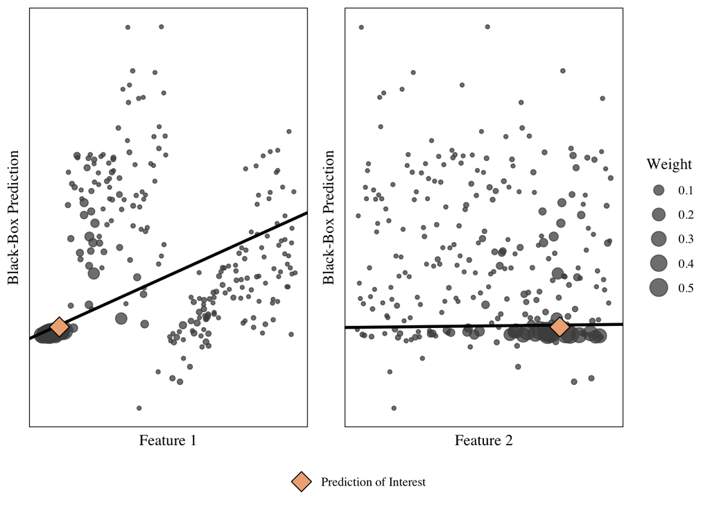

```r
# View the plot
lime_linear_concept
```

## Ridge Regression Explainer

```r
# Fits the explainer model (weighted ridge regression)
ridge_explainer <- glmnet(x = lime_data %>%
                            select(feature1, feature2) %>%
                            as.matrix(),
                          y = lime_data %>% pull(prediction),
                          weights = lime_data$distance,
                          family = "gaussian",
                          alpha = 0,
                          lambda = 1,
                          standardize = FALSE)

# Extract the coefficients from the explainer
ridge_b0 <- ridge_explainer$a0[[1]]
ridge_b1 <- ridge_explainer$beta[1,1]
ridge_b2 <- ridge_explainer$beta[2,1]

# Predictions versus feature 1
ridge_plot_feature1 <- ggplot(data = lime_data,
                        mapping = aes(x = feature1,
                                      y = prediction,
                                      size = distance)) +
  geom_point(color = "grey30",
             alpha = 0.75) +
  geom_abline(intercept = ridge_b0 +
                ridge_b2*prediction_of_interest$feature2,
              slope = ridge_b1,
              size = 1) +
  geom_point(data = prediction_of_interest,
             mapping = aes(x = feature1, y = prediction),
             fill = "#EFB084",
             color = "black",
             size = 5,
             shape = 23) +
  theme_linedraw(base_family = "Times") +
  labs(x = "Feature 1",
       y = "Black-Box Prediction") +
  theme(panel.grid.major = element_blank(),
        panel.grid.minor = element_blank(),
        axis.text.x = element_blank(),
        axis.ticks.x = element_blank(),
        axis.text.y = element_blank(),
        axis.ticks.y = element_blank(),
        legend.position = "none")

# Predictions versus feature 2
ridge_plot_feature2 <- ggplot(data = lime_data,
                        mapping = aes(x = feature2,
                                      y = prediction,
                                      size = distance)) +
  geom_point(color = "grey30",
             alpha = 0.75) +
  geom_abline(intercept = ridge_b0 +
                ridge_b1*prediction_of_interest$feature1,
              slope = ridge_b2,
              size = 1) +
  geom_point(data = prediction_of_interest,
             mapping = aes(x = feature2, y = prediction),
             fill = "#EFB084",
             color = "black",
             size = 5,
             shape = 23) +
  theme_linedraw(base_family = "Times") +
  labs(x = "Feature 2",
       y = "Black-Box Prediction") +
  theme(panel.grid.major = element_blank(),
        panel.grid.minor = element_blank(),
        axis.text.x = element_blank(),
        axis.ticks.x = element_blank(),
        axis.text.y = element_blank(),
        axis.ticks.y = element_blank(),
        legend.position = "none")

# Join the two feature plots
lime_ridge_plots <- plot_grid(ridge_plot_feature1,
                              ridge_plot_feature2,
                              size_legend,
                              ncol = 3,
                              rel_widths = c(0.4, 0.4, 0.1))

# Join the title, plots, legend, and caption into one figure
lime_ridge_concept <- plot_grid(lime_ridge_plots,
                                lime_legend,
                                ncol = 1,
                                rel_heights = c(0.9, 0.1))
```

This example shows that the explainer model is **not** doing a good job of capturing the local trend.

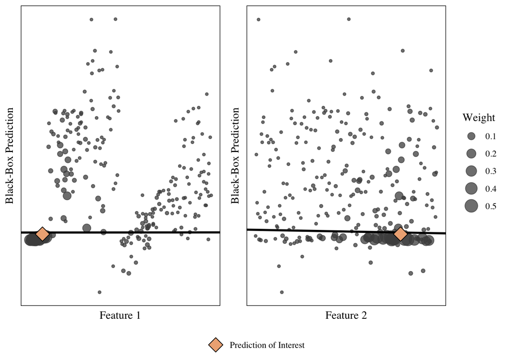

```r
# Preview the plot
lime_ridge_concept
```

# Proposed Bin Creation Methods

## The Data

The cleaning training and testing datasets are loaded in below.

```r
# Load in the training data (Hamby Data 173 and 252)
hamby173and252_train <- read.csv("../../../data/hamby173and252_train.csv")
```

## Subsampled Bins

One idea that I had to try to improve the lime explanations was to subsample from the training dataset before computing the quantiles. The proportion of observations with `samesource = FALSE` is very large in the training dataset, so that overwhelms the observations with `samesource = TRUE`. By subsampling, it might allow for better locations to bin the data. I wrote the code below to attempt to apply lime to a subsampled version of the training dataset.

```r
# Code saved for future use for the sampling data

# Create the data (with a set seed)
set.seed(20181128)
hamby173and252_train_sub <- hamby173and252_train %>%
  filter(samesource == FALSE) %>%
  slice(sample(1:length(hamby173and252_train$barrel1), 4500, replace = FALSE)) %>%
  bind_rows(hamby173and252_train %>% filter(samesource == TRUE))

# Save the subsampled data
write.csv(hamby173and252_train_sub, "../../data/hamby173and252_train_sub.csv", row.names = FALSE)

# Apply lime to the subsampled training data with the specified input options
hamby224_lime_explain_sub <- future_pmap(.l = as.list(hamby224_lime_inputs %>%
                                                        select(-case)),
                                         .f = run_lime, # run_lime is one of my helper functions
                                         train = hamby173and252_train_sub %>% select(rf_features),
                                         test = hamby224_test %>% arrange(case) %>% select(rf_features) %>% na.omit(),
                                         rfmodel = as_classifier(rtrees),
                                         label = "TRUE",
                                         nfeatures = 3,
                                         seed = TRUE) %>%
  mutate(training_data = factor("Subsampled"))

# Separate the lime and explain function results from the subsampled data
hamby224_lime_sub <- map(hamby224_lime_explain_sub, function(list) list$lime)
hamby224_explain_sub <- map_df(hamby224_lime_explain_sub, function(list) list$explain)

# Join the lime results from the full and subsampled training data
hamby224_lime <- c(hamby224_lime_full, hamby224_lime_sub)
hamby224_explain <- bind_rows(hamby224_explain_full, hamby224_explain_sub)
```

## Tree Based Bins

Heike suggested the idea of using classification trees to choose the cutoffs for the lime bins. That is, the divisions in the tree could be used as the bin cuts. This would allow us to automate the process and to obtain a penalty parameter since the trees give us nesting. (MSE + lambda * p where p is the from the number of trees multiplied by the number of …)

Heike wrote the function `treebink` to take x and y variables for fitting a tree and returning the cuts for $k$ bins based on the splits from the tree. The function is stored in the file `helper_functions.R`. Here is an example using the function below with the predictor variable of ccf.

```r
# Example using treebink
treebink(y = hamby173and252_train$samesource, x = hamby173and252_train$ccf, k = 5)
```

```
## [1] 0.493562 0.582999 0.688211 0.778397
```

However, there seems to be a problem with `treebink`. For certain variables, when a high number of bins is requested, the function returns more than the desired number of bins. Heike is going to look into this.

She recently updated the function `treebink` to run using the tree package. Here are some comments from her about the code:

“I’ve moved it from rpart to tree. I am not quite sure that the two packages are doing the exact same thing. They claim they do but they might be implemented a bit differently. What we are doing now is if there are too many splits, we look at the order in which the splits are made and roll back some of them. I haven’t found a case that doesn’t work, but obviously that doesn’t show that there isn’t any :)”

I wrote the function `mylime`, which adds an option in the `lime` function from the LIME package to use Heike’s function `treebink` to obtain tree based bins. This function is also included in the file `helper_functions.R`. The output from `mylime` can then be input into the `explain` function to obtain explanations. I was able to rerun all of the code for creating the `hamby224_test_explain` dataset with the explanations from the tree based bins included for 2 to 6 bins.